This area is used to setup R studio for this project

```r
# LIBRARIES ####
library(maps) # lat and long
library(usmap)
library(caret) # confusion Matrix
library(e1071) # navebayes
library(class) # knn
#library(tm) #text mining library provides the stopwords() function
library(tidyr)
#library(plyr)
#library(jsonlite)
library(dplyr)
library(tidyverse)
library(stringr) # string manipulation
#library(mvtnorm)
library(ggplot2)
library(ggthemes) # Plot Themes
library(plotly)
```

Import in all datasets

```r
# IMPORT DATASETS ####
# Import Beers data set
beers <- read.csv(choose.files(),header = T)
```

```r
# Import Breweries data set
breweries <- read.csv(choose.files(),header = T)
```

```r
# Import Breweries data set
state_abb_list <- read.csv(choose.files(),header = T)

# Change column names
colnames(state_abb_list)[1] <- c("Full_State")
colnames(state_abb_list)[3] <- c("State")
```

```r
# UNDERSTAND DATASETS ####
# What kind of data am I looking at
str(beers)
```

```
## 'data.frame':    2410 obs. of  7 variables:
##  $ Name      : chr  "Pub Beer" "Devil's Cup" "Rise of the Phoenix" "Sinister" ...
##  $ Beer_ID   : int  1436 2265 2264 2263 2262 2261 2260 2259 2258 2131 ...
##  $ ABV       : num  0.05 0.066 0.071 0.09 0.075 0.077 0.045 0.065 0.055 0.086 ...
##  $ IBU       : int  NA NA NA NA NA NA NA NA NA NA ...
##  $ Brewery_id: int  409 178 178 178 178 178 178 178 178 178 ...
##  $ Style     : chr  "American Pale Lager" "American Pale Ale (APA)" "American IPA" "American Double / Imperial IPA" ...
##  $ Ounces    : num  12 12 12 12 12 12 12 12 12 12 ...
```

```r
str(breweries)
```

```
## 'data.frame':    558 obs. of  4 variables:
##  $ Brew_ID: int  1 2 3 4 5 6 7 8 9 10 ...
##  $ Name   : chr  "NorthGate Brewing " "Against the Grain Brewery" "Jack's Abby Craft Lagers" "Mike Hess Brewing Company" ...
##  $ City   : chr  "Minneapolis" "Louisville" "Framingham" "San Diego" ...
##  $ State  : chr  " MN" " KY" " MA" " CA" ...
```

```r
str(state_abb_list)
```

```
## 'data.frame':    51 obs. of  3 variables:
##  $ Full_State: chr  "Alabama" "Alaska" "Arizona" "Arkansas" ...
##  $ abbrev    : chr  "Ala." "Alaska" "Ariz." "Ark." ...
##  $ State     : chr  "AL" "AK" "AZ" "AR" ...
```

```r
# REVIEW MISSING VALUES ####
# beers dataset has missing values in IBU & ABV column
view(beers)

## SFAE BEER DATASET CHECKPOINT ####
safe_beers = beers

# There is missing values in some of the rows not all.
```

Handling Missing Data Files for Question #3

```r
## Look at only NA Values in beers data set ####
beers_na = beers

# create a logical vector indicating which rows have missing values
na_rows <- apply(is.na(beers_na), 1, any)

beers_na <- beers_na[na_rows, ]

str(beers_na)
```

```
## 'data.frame':    1005 obs. of  7 variables:
##  $ Name      : chr  "Pub Beer" "Devil's Cup" "Rise of the Phoenix" "Sinister" ...
##  $ Beer_ID   : int  1436 2265 2264 2263 2262 2261 2260 2259 2258 2131 ...
##  $ ABV       : num  0.05 0.066 0.071 0.09 0.075 0.077 0.045 0.065 0.055 0.086 ...
##  $ IBU       : int  NA NA NA NA NA NA NA NA NA NA ...
##  $ Brewery_id: int  409 178 178 178 178 178 178 178 178 178 ...
##  $ Style     : chr  "American Pale Lager" "American Pale Ale (APA)" "American IPA" "American Double / Imperial IPA" ...
##  $ Ounces    : num  12 12 12 12 12 12 12 12 12 12 ...
```

```r
#### Check and make sure I only see na in ABV(3) and IBU(4) columns ####
#which(is.na(beers_na), arr.ind = TRUE)
```

```r
#### Count how many objects are NA in the ABV column ####
ABV_na_Index <- which(is.na(beers_na$ABV), arr.ind = TRUE)
# 62 rows

ABV_CNT <- length(ABV_na_Index)

ABV_CNT
```

```
## [1] 62
```

```r
#### Count how many objects are NA in the IBU column ####
IBU_na_Index <- which(is.na(beers_na$IBU), arr.ind = TRUE)
# 1005 rows

IBU_Cnt <- length(IBU_na_Index)

IBU_Cnt
```

```
## [1] 1005
```

Investigation Code Chunk

```r
#### Understand which rows are missing both ABV and IBU ####
#str(which(is.na(beers_na$IBU) & is.na(beers_na$ABV), arr.ind = TRUE))

#which(is.na(beers_na$IBU) & is.na(beers_na$ABV), arr.ind = TRUE)

# 62 matches so for every ABV NA there will also be an NA IBU
# Check this theory
#beers_na[112, ] # Double Play Pilsner | 1541
#beers_na[117, ] # N Street Drive-In 50th Anniversary IPA |  1025
#beers_na[123, ] # Professor Black | 2490
#beers_na[124, ] # Little Boss | 2489
#beers_na[125, ] # Van Dayum! | 2488
```

Plot to show the missing values in correlation to the size of beer, and we see that the smaller beers have more missing values

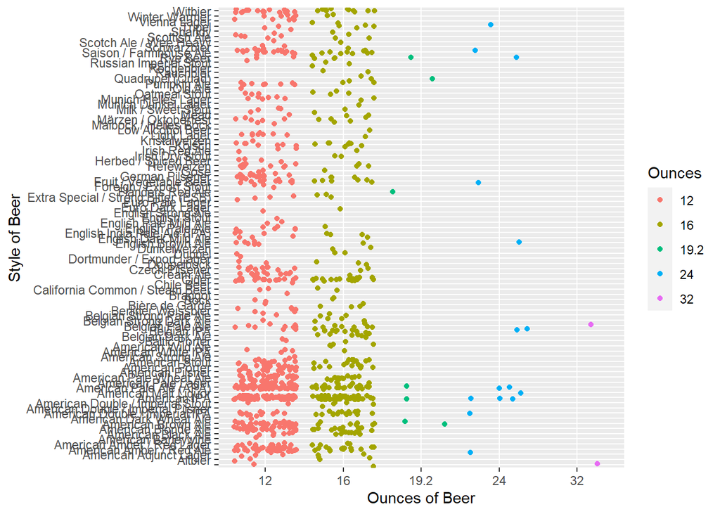

```r
# MIssing Data PLot 2 ####
beers_na %>%
  ggplot() +
  geom_point(aes(y = as.factor(Style), x = as.factor(Ounces), color = as.factor(Ounces)), position = "jitter") +
  xlab("Ounces of Beer") +
  ylab("Style of Beer") +
  labs(color = "Ounces")
```

```r
# EXPORT NA FIELDS TO CSV ####
write.csv(beers_na, "Missing_Data.csv", row.names = T)
```

Merge Datasets together for Question #2

```r
# MERGE SAFE_BEERS AND ALL BEER DATA ####
# Rename Column Names for Consistency and Merge Process
colnames(beers)[5] <- c("Brew_ID")
colnames(beers)[1] <- c("Beer_Name")
colnames(breweries)[2] <- c("Brewery")

colnames(safe_beers)[5] <- c("Brew_ID")
colnames(safe_beers)[1] <- c("Beer_Name")


# Merge Data
#beer_ds <- merge(beers,breweries, by = "Brew_ID")

## CREATE ALL_BEER_DS ####
all_beer_ds <- merge(safe_beers,breweries, by = "Brew_ID")

# Check Data
#str(beer_ds)
str(all_beer_ds)
```

```
## 'data.frame':    2410 obs. of  10 variables:
##  $ Brew_ID  : int  1 1 1 1 1 1 2 2 2 2 ...
##  $ Beer_Name: chr  "Get Together" "Maggie's Leap" "Wall's End" "Pumpion" ...
##  $ Beer_ID  : int  2692 2691 2690 2689 2688 2687 2686 2685 2684 2683 ...
##  $ ABV      : num  0.045 0.049 0.048 0.06 0.06 0.056 0.08 0.125 0.077 0.042 ...
##  $ IBU      : int  50 26 19 38 25 47 68 80 25 42 ...
##  $ Style    : chr  "American IPA" "Milk / Sweet Stout" "English Brown Ale" "Pumpkin Ale" ...
##  $ Ounces   : num  16 16 16 16 16 16 16 16 16 16 ...
##  $ Brewery  : chr  "NorthGate Brewing " "NorthGate Brewing " "NorthGate Brewing " "NorthGate Brewing " ...
##  $ City     : chr  "Minneapolis" "Minneapolis" "Minneapolis" "Minneapolis" ...
##  $ State    : chr  " MN" " MN" " MN" " MN" ...
```

Handle Missing Values for Question #3

```r
## Drop Missing Values - Use Until Loop is Fixed ####
# all_beer_ds = drop_na(all_beer_ds)
# DROP ------------------------------------
```

```r
# HANDLING MISSING VALUES WITH CUMPUTED VALUES ####
all_beer_ds$Style = as.factor(all_beer_ds$Style)

# Grab the index of each NA row by ABV and IBU ####
index_safe_beers_ABV = which(is.na(all_beer_ds$ABV))
index_safe_beers_IBU = which(is.na(all_beer_ds$IBU))

## FInd Median based on Styel ####
style_ABV_cnt <- aggregate(ABV ~ Style, all_beer_ds, median)
style_IBU_cnt <- aggregate(IBU ~ Style, all_beer_ds, median)
```

```r
# Style with no IBU at all like Rauchier and replace with median first then run the loop
missing_IBU <- setdiff(levels(all_beer_ds$Style), levels(as.factor(as.character(style_IBU_cnt$Style))))

## Median IBU for all beers ####
no_style_IBU_cnt <- median(style_IBU_cnt$IBU)


# Capture beer index for Loop
Ale_index <- which(grepl("Ale", all_beer_ds$Style))
lager_index <- which(grepl("Lager", all_beer_ds$Style))
Stout_index <- which(grepl("Stout", all_beer_ds$Style))
Mead_index <- which(grepl("Mead", all_beer_ds$Style))
Cider_index <- which(grepl("Cider", all_beer_ds$Style))
missing_index_IBU <- which(is.na(all_beer_ds$IBU))



# Update all IPA beers with the following value
all_beer_ds$IBU[all_beer_ds$Style == "IPA" & is.na(all_beer_ds$IBU)] <- 55

# ALE Replacement
for (a in 1:length(Ale_index)) {

  all_beer_ds[Ale_index[a], "IBU"] = 35
}



# lager Replacement
for (l in 1:length(lager_index)) {

  all_beer_ds[lager_index[l], "IBU"] = 8
}

# Stout Replacement
for (s in 1:length(Stout_index)) {

  all_beer_ds[Stout_index[s], "IBU"] = no_style_IBU_cnt
}


# Mead Replacement
for (m in 1:length(Mead_index)) {

  all_beer_ds[Mead_index[m], "IBU"] = 0
}


# Cider Replacement
for (c in 1:length(Cider_index)) {

  all_beer_ds[Cider_index[c], "IBU"] = 0
}
```

```r
# Catch the leftovers
for (g in 1:length(missing_index_IBU)) {

  # General Replacement
  all_beer_ds[missing_index_IBU[g], "IBU"] = no_style_IBU_cnt

}
```

```r
## ABV LOOP MEDIAN ####
for (i in 1:length(index_safe_beers_ABV)) {
  all_beer_ds[index_safe_beers_ABV[i], "ABV"] = style_ABV_cnt[style_ABV_cnt$Style == all_beer_ds[index_safe_beers_ABV[i], "Style"], "ABV"]
}
```

```r
# REMOVE STRING VALUES FROM NUMERIC COLUMN SO MATHMATICAL FORUMALS WILL WORK ####

## Beers_ds CHECKPOINT ####
beers_ds <- all_beer_ds

#beers_ds$State = as.factor(beers_ds$State)
#beers_ds$IBU = as.numeric(beers_ds$IBU)
#beers_ds$ABV = as.numeric(beers_ds$ABV)

#beers_ds <- beers_ds %>%
  #filter(!is.character(IBU))

#beers_ds <- beers_ds %>%
  #filter(!is.character(ABV))

#beers_ds = drop_na(beers_ds)

str(beers_ds)
```

```
## 'data.frame':    2410 obs. of  10 variables:
##  $ Brew_ID  : int  1 1 1 1 1 1 2 2 2 2 ...
##  $ Beer_Name: chr  "Get Together" "Maggie's Leap" "Wall's End" "Pumpion" ...
##  $ Beer_ID  : int  2692 2691 2690 2689 2688 2687 2686 2685 2684 2683 ...
##  $ ABV      : num  0.045 0.049 0.048 0.06 0.06 0.056 0.08 0.125 0.077 0.042 ...
##  $ IBU      : num  50 25 35 35 25 47 68 80 25 35 ...
##  $ Style    : Factor w/ 100 levels "","Abbey Single Ale",..: 16 77 48 83 22 57 12 46 77 18 ...
##  $ Ounces   : num  16 16 16 16 16 16 16 16 16 16 ...
##  $ Brewery  : chr  "NorthGate Brewing " "NorthGate Brewing " "NorthGate Brewing " "NorthGate Brewing " ...
##  $ City     : chr  "Minneapolis" "Minneapolis" "Minneapolis" "Minneapolis" ...
##  $ State    : chr  " MN" " MN" " MN" " MN" ...
```

Compute the median alcohol content and international bitterness unit for each state. Question #4

```r
# DATAFRAME FOR MEDIAN AND MEAN VALUES ####
# WILL BE USED FOR PLOTTING
plot_ds <- as.data.frame(matrix(nrow = 50, ncol = 0))

plot_ds
```

```
## data frame with 0 columns and 50 rows
```

```r
# Compute the median alcohol content and international bitterness unit for each state. ####
## IBU Median by State ####
plot_ds <- beers_ds %>% group_by(State) %>%
  summarise(median = median(IBU))

plot_ds <- arrange(plot_ds, desc(median))

colnames(plot_ds)[2] <- c("IBU_Median")

plot_ds
```

```
## # A tibble: 51 × 2
##    State IBU_Median
##    <chr>      <dbl>
##  1 " AK"         35
##  2 " AL"         35
##  3 " CA"         35
##  4 " FL"         35
##  5 " IA"         35
##  6 " ID"         35
##  7 " KS"         35
##  8 " KY"         35
##  9 " MN"         35
## 10 " MS"         35
## # … with 41 more rows
```

```r
## ABV median by State ####
ABV_Median <- beers_ds %>% group_by(State) %>%
  summarise(median = median(ABV))

ABV_Median <- arrange(ABV_Median, desc(median))

ABV_Median
```

```
## # A tibble: 51 × 2
##    State median
##    <chr>  <dbl>
##  1 " KY" 0.065
##  2 " DC" 0.0625
##  3 " NV" 0.062
##  4 " WV" 0.062
##  5 " NM" 0.061
##  6 " AL" 0.06
##  7 " CO" 0.06
##  8 " CT" 0.06
##  9 " DE" 0.06
## 10 " MI" 0.06
## # … with 41 more rows
```

```r
# Merge data with Plot data
plot_ds <- merge(plot_ds, ABV_Median, by = "State")

colnames(plot_ds)[3] <- c("ABV_Median")

plot_ds
```

```
##    State IBU_Median ABV_Median
## 1     AK       35.0    0.05600
## 2     AL       35.0    0.06000
## 3     AR       25.0    0.05200
## 4     AZ       25.0    0.05500
## 5     CA       35.0    0.05800
## 6     CO       25.0    0.06000
## 7     CT       25.0    0.06000
## 8     DC       25.0    0.06250
## 9     DE       30.0    0.06000
## 10    FL       35.0    0.05550
## 11    GA       25.0    0.05500
## 12    HI       25.0    0.05400
## 13    IA       35.0    0.05550
## 14    ID       35.0    0.05650
```

[output cut: 37 more lines]

```r
# MERGE MEDIAN DATASET WITH STATE ABBREVIATIONS ####
plt_ds = plot_ds

# Change from factor to character
plt_ds$State <- as.character(plt_ds$State)

# Remove spaces in state field
plt_ds$State <- gsub("\\s", "", plt_ds$State)

# MERGE median values
#all_beer_ds <- merge(all_beer_ds, plt_ds, by = "State")

# Left Merge the data
plt_ds <- merge(plt_ds, state_abb_list, by = "State", all.x = T )

str(plt_ds)
```

```
## 'data.frame':    51 obs. of  5 variables:
##  $ State     : chr  "AK" "AL" "AR" "AZ" ...
##  $ IBU_Median: num  35 35 25 25 35 25 25 25 30 35 ...
##  $ ABV_Median: num  0.056 0.06 0.052 0.055 0.058 0.06 0.06 0.0625 0.06 0.0555 ...
##  $ Full_State: chr  "Alaska" "Alabama" "Arkansas" "Arizona" ...
##  $ abbrev    : chr  "Alaska" "Ala." "Ark." "Ariz." ...
```

```r
# MERGE AND CREATE FULL DATASET FOR CHARTS ####
## ALL BEERS DS BACKUP CHECK POINT ####
backup_ds = all_beer_ds

# RECOVER DATA
#all_beer_ds = backup_ds

# Remove spaces in state field
#all_beer_ds$State <- gsub("\\s", "", all_beer_ds$State)

#all_beer_ds <- merge(all_beer_ds, state_abb_list, by = "State", all.x = T )

#str(beer_ds)
str(all_beer_ds)
```

```
## 'data.frame':    2410 obs. of  10 variables:
##  $ Brew_ID  : int  1 1 1 1 1 1 2 2 2 2 ...
##  $ Beer_Name: chr  "Get Together" "Maggie's Leap" "Wall's End" "Pumpion" ...
##  $ Beer_ID  : int  2692 2691 2690 2689 2688 2687 2686 2685 2684 2683 ...
##  $ ABV      : num  0.045 0.049 0.048 0.06 0.06 0.056 0.08 0.125 0.077 0.042 ...
##  $ IBU      : num  50 25 35 35 25 47 68 80 25 35 ...
##  $ Style    : Factor w/ 100 levels "","Abbey Single Ale",..: 16 77 48 83 22 57 12 46 77 18 ...
##  $ Ounces   : num  16 16 16 16 16 16 16 16 16 16 ...
##  $ Brewery  : chr  "NorthGate Brewing " "NorthGate Brewing " "NorthGate Brewing " "NorthGate Brewing " ...
##  $ City     : chr  "Minneapolis" "Minneapolis" "Minneapolis" "Minneapolis" ...
##  $ State    : chr  " MN" " MN" " MN" " MN" ...
```

```r
str(backup_ds)
```

```
## 'data.frame':    2410 obs. of  10 variables:
##  $ Brew_ID  : int  1 1 1 1 1 1 2 2 2 2 ...
##  $ Beer_Name: chr  "Get Together" "Maggie's Leap" "Wall's End" "Pumpion" ...
##  $ Beer_ID  : int  2692 2691 2690 2689 2688 2687 2686 2685 2684 2683 ...
##  $ ABV      : num  0.045 0.049 0.048 0.06 0.06 0.056 0.08 0.125 0.077 0.042 ...
##  $ IBU      : num  50 25 35 35 25 47 68 80 25 35 ...
##  $ Style    : Factor w/ 100 levels "","Abbey Single Ale",..: 16 77 48 83 22 57 12 46 77 18 ...
##  $ Ounces   : num  16 16 16 16 16 16 16 16 16 16 ...
##  $ Brewery  : chr  "NorthGate Brewing " "NorthGate Brewing " "NorthGate Brewing " "NorthGate Brewing " ...
##  $ City     : chr  "Minneapolis" "Minneapolis" "Minneapolis" "Minneapolis" ...
##  $ State    : chr  " MN" " MN" " MN" " MN" ...
```

```r
# MERGE STATE LAT AND LONG | FIX THIS IS DOUBLING ####

# Has Lat and long cordinates
#US_Map <- map_data("world") %>% filter(region=="USA")

# rename column for merge
#colnames(US_Map)[6] <- c("Full_State")


#str(US_Map)
#str(plt_ds)

#view(US_Map)


# Left Merge
#plt_ds = merge(plt_ds, US_Map, by = "Full_State", all.x = T)


#str(plt_ds)
```

```r
# How many breweries are present in each state? | State_cnt ####
state_cnt <- all_beer_ds %>% count(State, sort = T)

colnames(state_cnt)[2] <- "Number_of_States"

state_cnt <- arrange(state_cnt, desc(Number_of_States))

# Remove spaces in state field
state_cnt$State <- gsub("\\s", "", state_cnt$State)

# Left Merge
state_cnt = merge(state_cnt, state_abb_list, by = "State", all.y = T)


str(state_cnt)
```

```
## 'data.frame':    51 obs. of  4 variables:
##  $ State           : chr  "AK" "AL" "AR" "AZ" ...
##  $ Number_of_States: int  25 10 5 47 183 265 27 8 2 58 ...
##  $ Full_State      : chr  "Alaska" "Alabama" "Arkansas" "Arizona" ...
##  $ abbrev          : chr  "Alaska" "Ala." "Ark." "Ariz." ...
```

[figure not shown]

```r
# PLOT1 Facet Wrap| How many breweries are present in each state? ####
state_cnt %>% arrange(state_cnt, desc(Number_of_States)) %>%
  ggplot(aes(x = Number_of_States, fill = Full_State)) +
  geom_histogram() +
  xlab("Number of Breweries by States") +
  ylab("") +
  facet_wrap(Number_of_States ~ Full_State) +
  scale_y_discrete() +
  theme(legend.position = "none")
```

[figure not shown]

```r
# PLOT2 Bar Chart| How many breweries are present in each state? ####
Top_Ten <- state_cnt[order(-state_cnt$Number_of_States), ]

head(Top_Ten, 10) %>%
  ggplot(aes(reorder(Number_of_States, x = Full_State), x = Number_of_States, fill = Full_State, color = "red")) +
  geom_bar(stat = "identity") +
  geom_text(aes(label = Number_of_States), size = 4, hjust = 1, color = "black") +
  xlab("Number of Breweries") +
  ylab("State") +
  theme(legend.position = "none") +
  scale_fill_brewer(palette = "YlOrRd")
```

```r
# ?color
```

Median Charts for Question #4

Bar Charts to compare the Median value of ABV vs IBU by state

```r
Top_5_IBU <- plt_ds[order(-plt_ds$IBU_Median), ]
Top_5_ABV <- plt_ds[order(-plt_ds$ABV_Median), ]


# IBU CHART
p3 <- head(Top_5_IBU, 5) %>%
  ggplot(aes(reorder(IBU_Median, x = Full_State), x = IBU_Median, fill = IBU_Median)) +
  geom_bar(stat = "identity") +
  xlab("IBU Median") +
  ylab("State")  +
  scale_fill_gradient(low = "black", high = "red")



# ABV CHART
?scale_fill_gradient
```

```
## starting httpd help server ... done
```

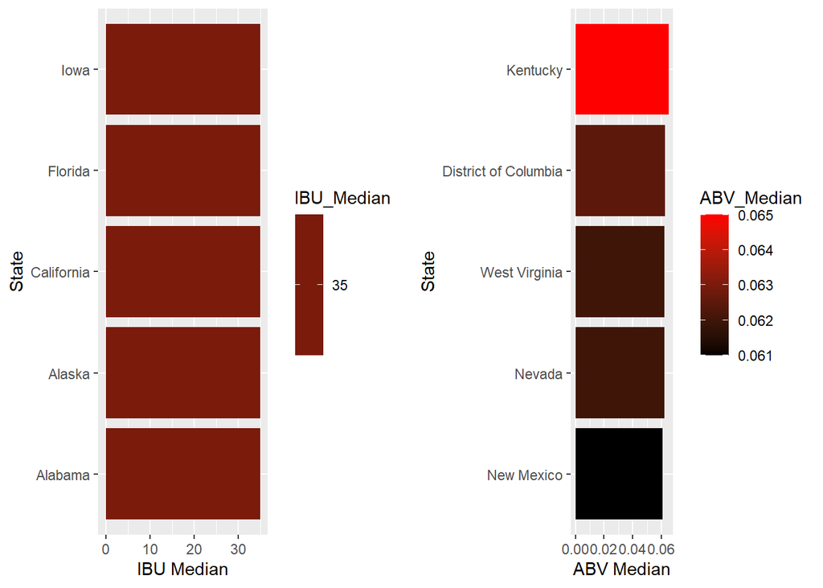

```r
p4 <- head(Top_5_ABV, 5) %>%
  ggplot(aes(reorder(ABV_Median, x = Full_State), x = ABV_Median, fill = ABV_Median)) +
  geom_bar(stat = "identity") +
  xlab("ABV Median") +
  ylab("State") +
  scale_fill_gradient(low = "black", high = "red")




cowplot::plot_grid(p3, p4, ncol = 2)
```

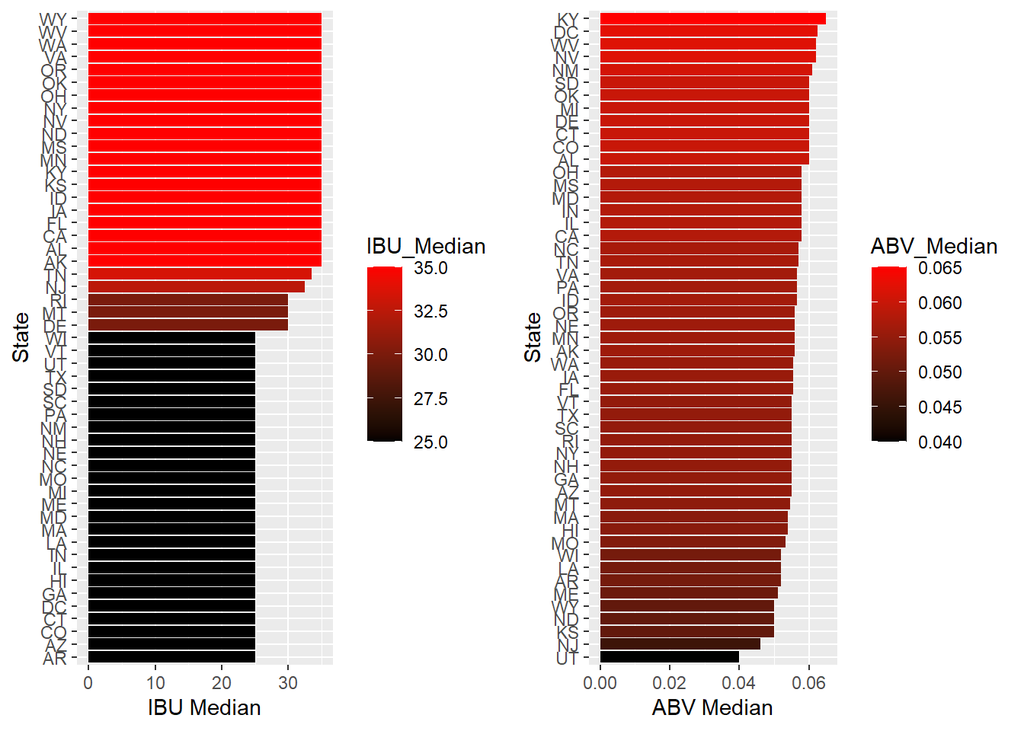

```r
# IBU CHART
p1 <- plt_ds %>% ggplot(aes(reorder(IBU_Median, x = State), x = IBU_Median, fill = IBU_Median)) +
  geom_bar(stat = "identity") +
  xlab("IBU Median") +
  ylab("State")  +
  scale_fill_gradient(low = "black", high = "red")



# ABV CHART
?scale_fill_gradient
p2 <- plt_ds %>% ggplot(aes(reorder(ABV_Median, x = State), x = ABV_Median, fill = ABV_Median)) +
  geom_bar(stat = "identity") +
  xlab("ABV Median") +
  ylab("State") +
  scale_fill_gradient(low = "black", high = "red")




cowplot::plot_grid(p1, p2, ncol = 2)
```

Breakdown of of Median values by State

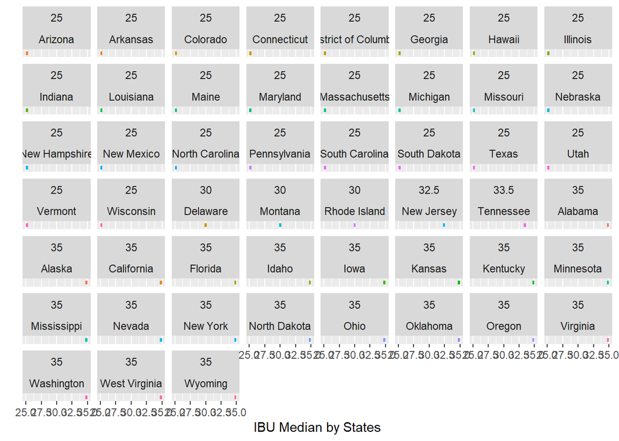

```r
# PLOT IBU Median by States ####
plt_ds %>% arrange(IBU_Median, desc(Full_State)) %>%
  ggplot(aes(x = IBU_Median, fill = Full_State)) +
  geom_histogram() +
  xlab("IBU Median by States") +
  ylab("") +
  facet_wrap(IBU_Median ~ Full_State) +
  scale_y_discrete() +
  theme(legend.position = "none")
```

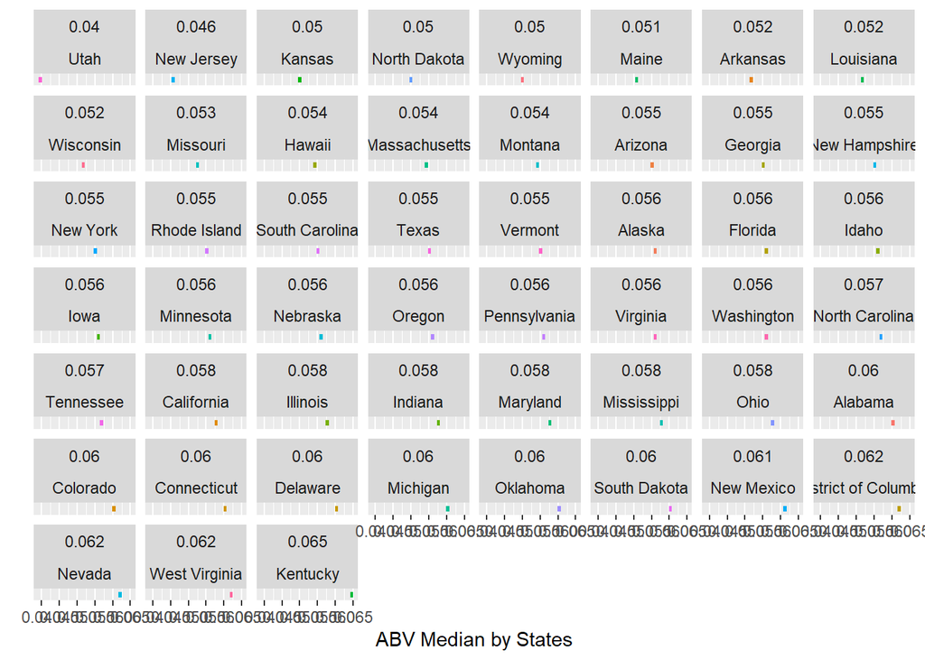

```r
# FIX ROUNDING ####
plt_ds$ABV_Median <- round(plt_ds$ABV_Median, digits = 3)

# PLOT ABV Median by States ####
plt_ds %>% arrange(ABV_Median, desc(Full_State)) %>%
  ggplot(aes(x = ABV_Median, fill = Full_State)) +
  geom_histogram() +
  xlab("ABV Median by States") +
  ylab("") +
  facet_wrap(ABV_Median ~ Full_State) +
  scale_y_discrete() +
  theme(legend.position = "none")
```

Which state has the maximum alcoholic (ABV) beer? Question #5

```r
# IBU CHART
Max_ABV <- head(Top_5_ABV, 1)
Max_ABV$Lat = 37.8393
Max_ABV$Long = 84.2700

Max_IBU <- head(Top_5_IBU, 1)
Max_IBU$Lat = 64.2008
Max_IBU$Long = 149.4937
```

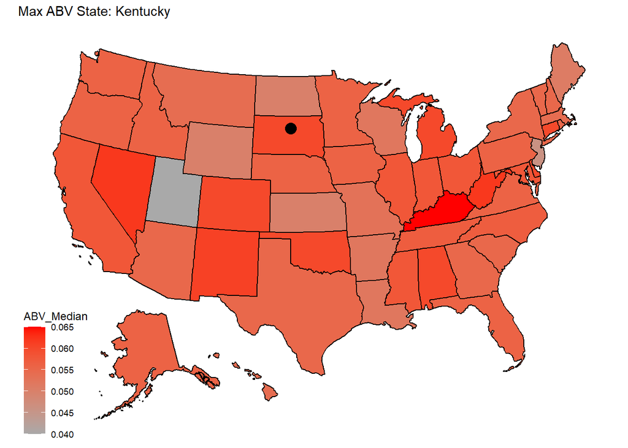

```r
median_map <- plt_ds

colnames(median_map)[1] <- c("state")
colnames(Max_ABV)[1] <- c("state")
colnames(Max_IBU)[1] <- c("state")



plot_usmap(data = median_map, values = "ABV_Median") +
  geom_point( y = 37.8393, x = 84.2700, color = "black", size = 4, shape = 16) +
  labs(title = "Max ABV State: Kentucky") +
  scale_fill_gradient(low = "dark grey", high = "red")
```

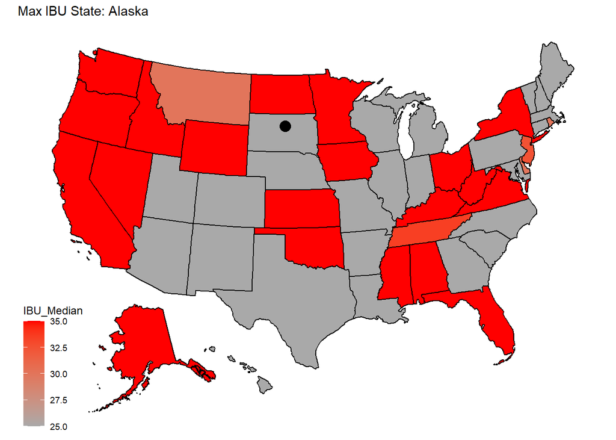

```r
plot_usmap(data = median_map, values = "IBU_Median") +
  geom_point( y = 61.2176, x = 149.8997, color = "black", size = 4, shape = 16) +
  labs(title = "Max IBU State: Alaska") +
  scale_fill_gradient(low = "dark grey", high = "red")
```

Question #7: Is there an apparent relationship between the bitterness of the beer and its alcoholic content?

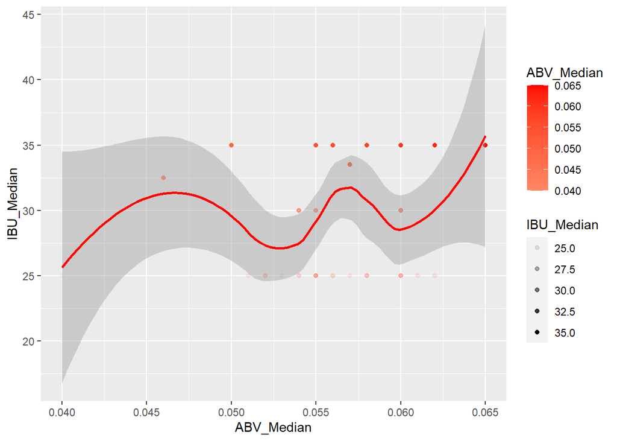

```r
# MEDIAN PLOT | relationship between IBU and ABV ####
plt_ds %>% ggplot() +
  geom_point(aes(x = ABV_Median , y = IBU_Median, color = ABV_Median, alpha = IBU_Median)) +
  geom_smooth(aes(x = ABV_Median , y = IBU_Median), color = "red") +
  scale_color_gradient2(low = "black", high = "red")
```

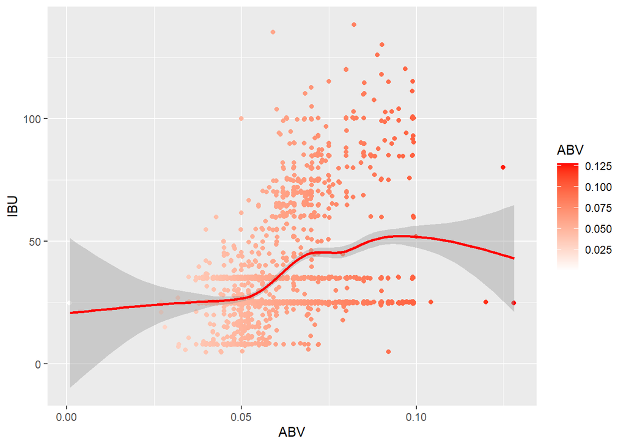

```r
# All Data PLOT | relationship between IBU and ABV ####
all_beer_ds %>% ggplot() +
  geom_point(aes(x = ABV, y = IBU, color = ABV), position = "jitter") +
  geom_smooth(aes(x = ABV, y = IBU, color = IBU), color = "red") +
  scale_color_gradient2(low = "black", high = "red")
```

What is the probability of picking a beer like Budweiser lager in this list of craft beers.

```r
# KNN Classification | FOR PRESENTATION ####
train = all_beer_ds

test = data.frame(ABV = .05, IBU = .12)

#all_beer_ds[, 5:6]
class <- knn(train[, 4:5], test, train$Style, k = 5, prob = T)

class
```

```
## [1] Gose
## attr(,"prob")
## [1] 0.4
## 100 Levels:  Abbey Single Ale Altbier ... Witbier
```

```r
#table(class, test)
```

Question #8 - difference with respect to IBU and ABV between IPAs (India Pale Ales) and other types of Ale (any beer with “Ale” in its name other than IPA).

```r
# Create KNN Train and Test Datasets ####

train2 = train[grepl("Ale|IPA", train$Style), ] # Everything Ale and IPA

train2$Classification = ifelse(grepl("\\bAle\\b", train2$Style), "Ale", "IPA" )

# ------------------------ #

train3 = train2[!grepl("\\bIPA\\b", train2$Style), ] # ONLY ALE

test2 = train2[grepl("\\bIPA\\b", train2$Style), ] # ONLY IPA

#str(train2)

#str(train3)

#str(test2)
```

What is the probability that we will find similar style beers within the entire dataset based off the ABV and IBU

```r
class4 <- knn.cv(train2[, c(4:5)], train2$Classification, k = 5, prob = T)

# table(class5, train2$Style)

confusionMatrix(table(class4, train2$Classification))
```

```
## Confusion Matrix and Statistics
##
##
## class4 Ale IPA
##    Ale 922  79
##    IPA  54 479
##
##                Accuracy : 0.9133
##                  95% CI : (0.8981, 0.9269)
##     No Information Rate : 0.6362
##     P-Value [Acc > NIR] : < 2e-16
##
##                   Kappa : 0.8109
##
##  Mcnemar's Test P-Value : 0.03743
##
##             Sensitivity : 0.9447
##             Specificity : 0.8584
##          Pos Pred Value : 0.9211
##          Neg Pred Value : 0.8987
##              Prevalence : 0.6362
##          Detection Rate : 0.6010
##    Detection Prevalence : 0.6525
##       Balanced Accuracy : 0.9015
##
##        'Positive' Class : Ale
##
```